# An introduction to spatial thinking and analysis using R as a crime mapping tool

## Neighbours for our LSOAs

Real LSOAs are not squares, but `poly2nb()` works the same way. By default it uses queen contiguity:

```r
nb_queen <- poly2nb(study_lsoa, queen = TRUE)
nb_queen
```

```
Neighbour list object:
Number of regions: 43
Number of nonzero links: 186
Percentage nonzero weights: 10.05949
Average number of links: 4.325581
```

Read the summary. It tells us the number of areas (regions), the total number of links between neighbours, and the average number of neighbours per LSOA. A **link** is one area counting another as a neighbour. Here is the distribution of the number of neighbours:

```r
table(card(nb_queen))   # card() counts the neighbours of each area
```

```
 1  2  3  4  5  6  7  8
 1  6  5 13  8  5  4  1
```

Now the same with rook contiguity:

```r
nb_rook <- poly2nb(study_lsoa, queen = FALSE)
nb_rook
```

```
Neighbour list object:
Number of regions: 43
Number of nonzero links: 182
Percentage nonzero weights: 9.843158
Average number of links: 4.232558
```

There are slightly fewer links: a few LSOAs only touch at a corner. With irregular shapes like these, queen and rook usually give very similar results. On a grid they differ a lot.

### Drawing the neighbours

We can draw the links: a line between the centres of every pair of neighbours. This is a good way to check that the neighbours make sense:

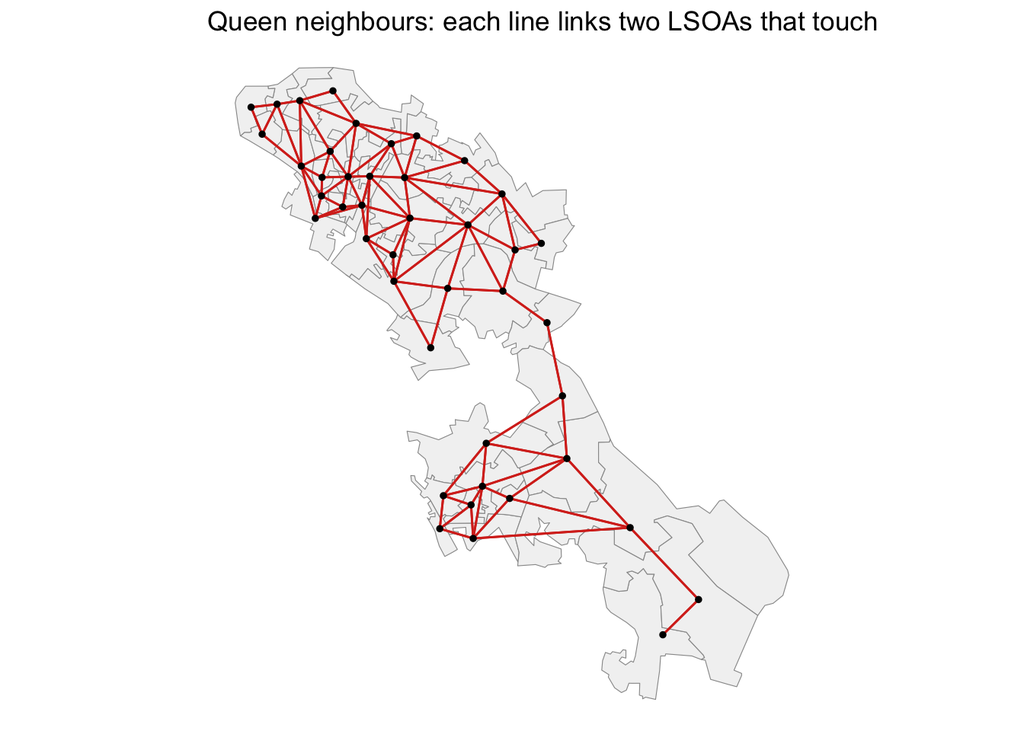

```r
lsoa_centres <- st_point_on_surface(st_geometry(study_lsoa))
links <- nb2lines(nb_queen, coords = lsoa_centres, as_sf = TRUE)

ggplot() +
  geom_sf(data = study_lsoa, fill = "grey95", colour = "grey60") +
  geom_sf(data = links, colour = "#d7301f", linewidth = 0.5) +
  geom_sf(data = lsoa_centres, size = 1) +
  labs(title = "Queen neighbours: each line links two LSOAs that touch") +
  theme_void()
```

Notice the LSOAs at the edge of the study area. They have fewer neighbours, because their neighbours outside our three wards are not in our data. This is the **edge effect**, and it is one reason not to cut a study area too tightly.

### One LSOA and its neighbours

Let’s look at the neighbours of one LSOA: the one containing Leeds Town Hall.

```r
town_hall <- st_sfc(st_point(c(-1.5492, 53.7999)), crs = 4326) |> st_transform(27700)
focus <- which(lengths(st_intersects(study_lsoa, town_hall)) > 0)

study_lsoa$LSOA21NM[focus]                  # the LSOA itself
```

```
[1] "Leeds 111A"
```

```r
study_lsoa$LSOA21NM[nb_queen[[focus]]]      # its queen neighbours
```

```
[1] "Leeds 063B" "Leeds 111B" "Leeds 111D" "Leeds 055J"
```

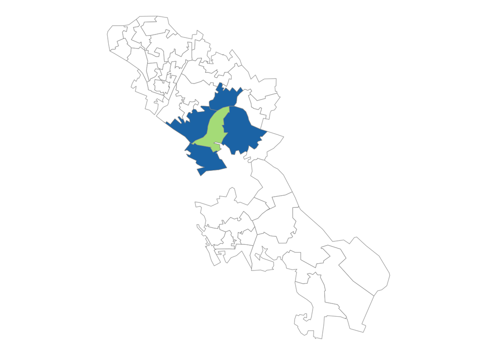

```r
ggplot() +
  geom_sf(data = study_lsoa, fill = "white", colour = "grey60") +
  geom_sf(data = study_lsoa[nb_queen[[focus]], ], fill = "#1f78b4", colour = "grey60") +
  geom_sf(data = study_lsoa[focus, ], fill = "#b2df8a", colour = "grey60") +
  theme_void()
```

## The spatial weights matrix

We now turn our list of neighbours into a **spatial weights matrix**, often written *W*. It is a table with one row and one column for each area: *n* by *n*, here 43 by 43. Each cell says how much area *j* (the column) counts as a neighbour of area *i* (the row).

### Binary weights

The simplest version has a 1 where two areas are neighbours, and a 0 where they are not. `nb2mat()` with `style = "B"` (for binary) builds it. A 43 by 43 table is a lot to look at, so let’s view the first 8 rows and columns:

```r
w_binary <- nb2mat(nb_queen, style = "B")
w_binary[1:8, 1:8]
```

```
    44 96 101 102 103 104 105 163
44   0  0   1   1   0   1   1   0
96   0  0   1   0   1   0   0   0
101  1  1   0   1   1   1   0   0
102  1  0   1   0   1   0   1   0
103  0  1   1   1   0   0   1   0
104  1  0   1   0   0   0   0   0
105  1  0   0   1   1   0   0   0
163  0  0   0   0   0   0   0   0
```

The row and column names are the LSOAs’ row numbers in the original Leeds file. We only see 8 of the 43 columns, so some rows look emptier than they are: their neighbours are further along.

- The **diagonal** is all zeroes: an area is not its own neighbour.
- The matrix is **symmetrical**: if LSOA 1 is a neighbour of LSOA 2, LSOA 2 is a neighbour of LSOA 1, with the same weight.
- Each row adds up to the number of neighbours:

```r
head(rowSums(w_binary))
```

```
 44  96 101 102 103 104
  5   4   6   4   4   4
```

### Row-standardised weights

In most analyses the matrix is **row-standardised**: each row is divided by its number of neighbours, so the weights in every row add up to 1. An LSOA with 4 neighbours gives each of them a weight of 1/4 = 0.25. One with 5 neighbours gives each 0.2. Use `style = "W"`:

```r
w_row <- nb2mat(nb_queen, style = "W")
round(w_row[1:8, 1:8], 2)
```

```
      44   96  101  102  103  104  105 163
44  0.00 0.00 0.20 0.20 0.00 0.20 0.20   0
96  0.00 0.00 0.25 0.00 0.25 0.00 0.00   0
101 0.17 0.17 0.00 0.17 0.17 0.17 0.00   0
102 0.25 0.00 0.25 0.00 0.25 0.00 0.25   0
103 0.00 0.25 0.25 0.25 0.00 0.00 0.25   0
104 0.25 0.00 0.25 0.00 0.00 0.00 0.00   0
105 0.33 0.00 0.00 0.33 0.33 0.00 0.00   0
163 0.00 0.00 0.00 0.00 0.00 0.00 0.00   0
```

```r
head(rowSums(w_row))
```

```
 44  96 101 102 103 104
  1   1   1   1   1   1
```

Why do this? Multiplying our values by a row-standardised matrix gives the **average of the neighbours’ values**. That is easy to interpret, and it makes results comparable between areas with many neighbours and areas with few.

Notice that the row-standardised matrix is **not symmetrical**. The influence of LSOA *j* on LSOA *i* depends on how many other neighbours *i* has.

## The spatial lag

The average value of an area’s neighbours is called the **spatial lag**. `spdep` works with weights as a list rather than a big matrix (it’s more efficient), so we convert with `nb2listw()`, then compute the lag:

```r
weights <- nb2listw(nb_queen, style = "W")
study_lsoa$burglary_lag <- lag.listw(weights, study_lsoa$burglary)

head(st_drop_geometry(study_lsoa[, c("LSOA21NM", "burglary", "burglary_lag")]))
```

```
      LSOA21NM burglary burglary_lag
44  Leeds 086A        4     5.000000
96  Leeds 085A        3     3.250000
101 Leeds 085B        2     3.333333
102 Leeds 086C        4     2.250000
103 Leeds 085C        2     2.500000
104 Leeds 085D        1     7.250000
```

For each LSOA, `burglary` is its own count, and `burglary_lag` is the average count in its neighbours. Mapped side by side, the lag looks like a smoothed version of the original:

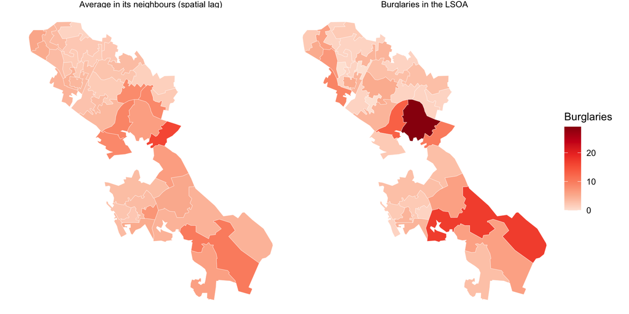

```r
bind_rows(
  study_lsoa |> mutate(measure = "Burglaries in the LSOA", value = burglary),
  study_lsoa |> mutate(measure = "Average in its neighbours (spatial lag)", value = burglary_lag)) |>
  ggplot() +
  geom_sf(aes(fill = value), colour = "white", linewidth = 0.1) +
  facet_wrap(~ measure) +
  scale_fill_distiller(palette = "Reds", direction = 1, name = "Burglaries") +
  theme_void()
```

## Measuring spatial autocorrelation: Moran’s I

If near things are alike, an area’s value should be correlated with its spatial lag. The **Moran scatterplot** shows exactly this: each LSOA’s value against the average of its neighbours.

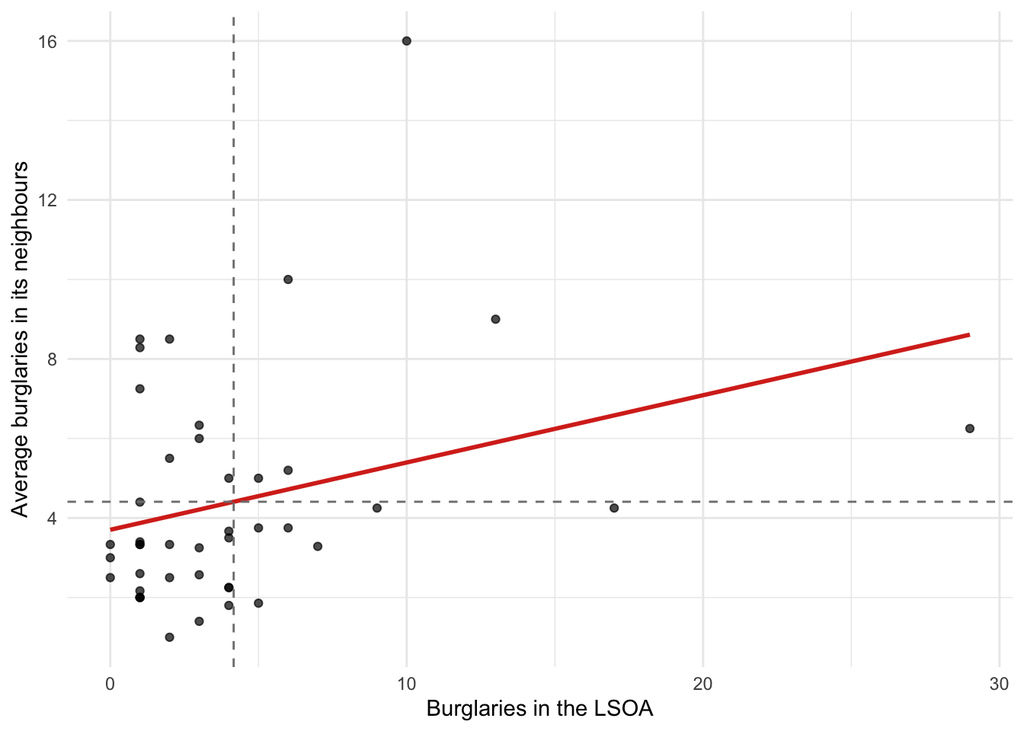

```r
ggplot(st_drop_geometry(study_lsoa), aes(burglary, burglary_lag)) +
  geom_point(alpha = 0.7) +
  geom_smooth(method = "lm", se = FALSE, colour = "#d7301f") +
  geom_vline(xintercept = mean(study_lsoa$burglary), linetype = "dashed", colour = "grey50") +
  geom_hline(yintercept = mean(study_lsoa$burglary_lag), linetype = "dashed", colour = "grey50") +
  labs(x = "Burglaries in the LSOA", y = "Average burglaries in its neighbours") +
  theme_minimal()
```

An upward slope means positive spatial autocorrelation. The dashed lines at the means split the plot into four quadrants: high values surrounded by high (top right), low by low (bottom left), and the two kinds of outlier.

The most widely used measure of spatial autocorrelation is **Moran’s I**. With row-standardised weights it is essentially the slope of that line. It usually lies between -1 and 1: positive values mean neighbours are alike, values near 0 mean no spatial pattern.

### Is it more than chance?

To test it, we do what we did by eye earlier: shuffle the values randomly between the LSOAs many times, compute Moran’s I for each shuffle, and see where our real value falls. This is a **permutation test** (also called a Monte Carlo test). With 999 shuffles:

```r
set.seed(2026)
moran_test <- moran.mc(study_lsoa$burglary, weights, nsim = 999)
moran_test
```

```
    Monte-Carlo simulation of Moran I

data:  study_lsoa$burglary
weights: weights
number of simulations + 1: 1000

statistic = 0.16923, observed rank = 964, p-value = 0.036
alternative hypothesis: greater
```

`statistic` is Moran’s I for the real data. The p-value is the share of shuffled maps with a Moran’s I at least as high as ours. A small p-value means a pattern this strong would rarely appear by chance: we reject the null hypothesis of spatial randomness.

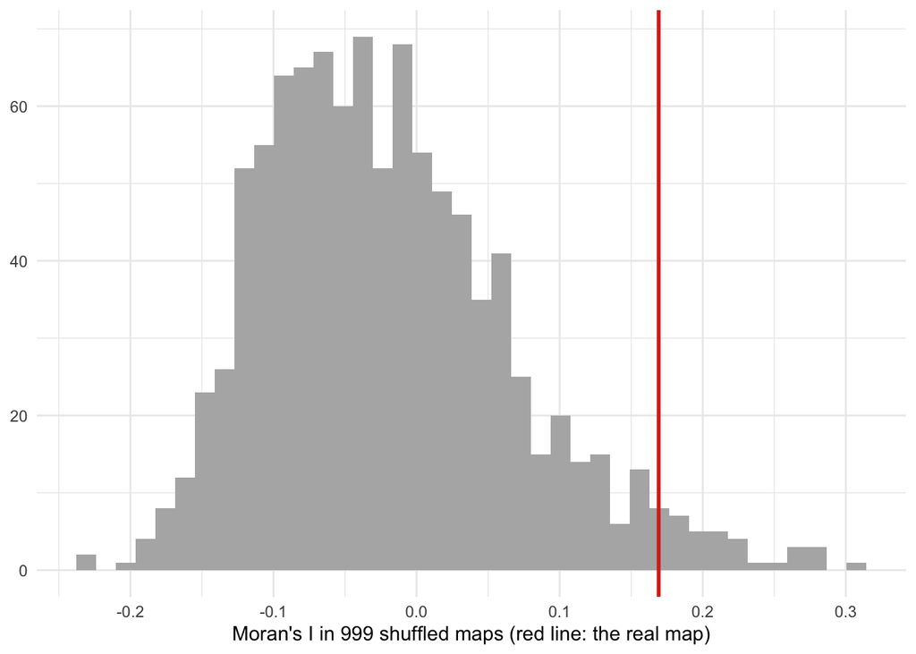

```r
ggplot(data.frame(I = moran_test$res[1:999]), aes(I)) +
  geom_histogram(bins = 40, fill = "grey70") +
  geom_vline(xintercept = moran_test$statistic, colour = "#d7301f", linewidth = 1) +
  labs(x = "Moran's I in 999 shuffled maps (red line: the real map)", y = NULL) +
  theme_minimal()
```

**ImportantThink**

Moran’s I is a **global** measure. It tells us how much the map as a whole is clustered, not *where* the clusters are. You can have local pockets of clustering without global autocorrelation, and the reverse. Where would you go to find the clusters?

### Your turn: does the definition of neighbour matter?

Rerun the test with rook neighbours instead of queen. Does Moran’s I change? Then try binary weights (`style = "B"`) instead of row-standardised.

```r
my_nb <- poly2nb(study_lsoa, queen = FALSE)
my_weights <- nb2listw(my_nb, style = "W")

set.seed(2026)
moran.mc(study_lsoa$burglary, my_weights, nsim = 999)
```

```
    Monte-Carlo simulation of Moran I

data:  study_lsoa$burglary
weights: my_weights
number of simulations + 1: 1000

statistic = 0.16574, observed rank = 960, p-value = 0.04
alternative hypothesis: greater
```

### Your turn: another crime type

Is every crime type equally autocorrelated? Get a different crime type from the API, count it per LSOA, and test it.

```r
my_crimes <- get_crimes("2026-08", "anti-social-behaviour") |>
  st_as_sf(coords = c("longitude", "latitude"), crs = 4326) |>
  st_transform(27700)

my_counts <- lengths(st_intersects(study_lsoa, my_crimes))

set.seed(2026)
moran.mc(my_counts, weights, nsim = 999)
```

```
    Monte-Carlo simulation of Moran I

data:  my_counts
weights: weights
number of simulations + 1: 1000

statistic = 0.22858, observed rank = 998, p-value = 0.002
alternative hypothesis: greater
```

## Spatial autocorrelation and regression

We won’t fit models today, but this is where spatial autocorrelation matters most for research.

- Ordinary regression assumes the observations are **independent**. Neighbouring areas usually are not: they share causes, and crime spills over from one to the next.
- If we ignore this, our standard errors are too small, and we find “significant” effects that are not really there.
- The check: fit the model, then look at the **residuals** (the differences between observed and predicted values). Map them, and test them for spatial autocorrelation with Moran’s I, using the same spatial weights we built here. Residuals should look random on the map.
- If they are spatially autocorrelated, **spatial regression** models build the weights matrix into the model: the **spatial lag model** includes the neighbours’ values of the outcome, and the **spatial error model** allows the errors of neighbours to be correlated.

Everything in those models rests on the decisions we made today: who counts as a neighbour, and how much they count. See the module’s final week for how to fit them.

**TipAlready know R? Stretch yourself**

1. **Local Moran’s I** (LISA; Anselin, 1995) finds *where* the clusters are: `localmoran_perm(study_lsoa$burglary, weights, nsim = 999)`. Map the high-high and low-low clusters. Adjust the p-values for multiple testing with `p.adjust()`.
2. Try **distance-based** neighbours: `dnearneigh(lsoa_centres, 0, 600)` (all LSOAs within 600 m) or `knn2nb(knearneigh(lsoa_centres, k = 5))` (the 5 nearest). How does Moran’s I change?
3. Use **rates** rather than counts (Part 2 shows how to get population from nomis). Does the conclusion change?
4. Fit a regression of burglary on population with `lm()`, then test its residuals with `lm.morantest()`.